# Classification excercise

Andres Ponce

# 1 Exercise with the Auto dataset

Developing a model to predict whether a given car gets high or low gas mileage based on the `Auto` dataset from the `ISLR` package.

## 1.1 Creating a binary variable

Binary variable, `mpg01`, that contains a 1 if `mpg` contains a value above its median, and a 0 if `mpg` contains a value below its median.

```r
median(Auto$mpg)
```

```
[1] 22.75
```

```r
mpg01<-ifelse(Auto$mpg>22.75, 1, 0)
table(mpg01)
```

```
mpg01
  0   1
196 196
```

```r
Auto$mpg01<- mpg01
```

## 1.2 Exploring the data visually

2. Exploring the data graphically in order to investigate the association between `mpg01` and the other features.

```
data in column(s) 'name' are not numeric and were ignored
```

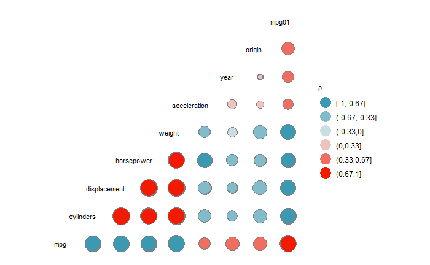

## 1.3 Spliting data into trainning and test set

- Spliting the data into a training set and a test set.

```r
require(caTools)
set.seed(123)   #  set seed to ensure you always have same random numbers generated
sample = sample.split(Auto,SplitRatio = 0.50) # splits the data in the ratio mentioned in SplitRatio. After splitting marks these rows as logical TRUE and the the remaining are marked as logical FALSE
train1 =subset(Auto,sample ==TRUE) # creates a training dataset named train1 with rows which are marked as TRUE
test1=subset(Auto, sample==FALSE)
```

## 1.4 Performing logistic regression and assessing error rate

- Performing logistic regression on the training data in order to predict `mpg01` using the variables that seemed most associated with `mpg01`.

```
Call:
glm(formula = mpg01 ~ cylinders + displacement + horsepower +
    weight, family = binomial, data = train1)

Deviance Residuals:
     Min        1Q    Median        3Q       Max
-2.18394  -0.34796  -0.00641   0.42897   3.14715

Coefficients:
               Estimate Std. Error z value Pr(>|z|)
(Intercept)  10.0725343  2.0759958   4.852 1.22e-06 ***
cylinders    -0.0447909  0.4382741  -0.102   0.9186
displacement -0.0113486  0.0101603  -1.117   0.2640
horsepower   -0.0472145  0.0188442  -2.506   0.0122 *
weight       -0.0012271  0.0009117  -1.346   0.1783
---
Signif. codes:  0 *** 0.001 ** 0.01 * 0.05 . 0.1   1

(Dispersion parameter for binomial family taken to be 1)

    Null deviance: 271.63  on 195  degrees of freedom
Residual deviance: 120.71  on 191  degrees of freedom
AIC: 130.71

Number of Fisher Scoring iterations: 7
```

```r
#one way to do it
train1$mpg01_pred<- as.numeric(NA) # create a numeric variable
train1$mpg01_pred[which(glm.probs < .5)] <- 0 # create 0 for probabilities <.5
train1$mpg01_pred[which(glm.probs >= .5)] <-1 #create 1 for probabilities >.5
table(train1$mpg01_pred,train1$mpg01) #confusion matrix
```

```
     0  1
  0 88  9
  1 12 87
```

```r
88+87 #correct predictions 175
```

```
[1] 175
```

```r
88+87/196 # fraction by which the prediction was correct
```

```
[1] 88.44388
```

```r
12+9/196
```

```
[1] 12.04592
```

## 1.5 K Nearest Neighbor estimation

- I perform a KNN estimation using k = 5 yields which yields the best result for this data performance.

```r
#normalizing and scaling variables for knn
trainX <- train1[,names(train1) != "mpg01"]
preProcValues <- preProcess(x = trainX,method = c("center", "scale"))
preProcValues
```

```
Created from 196 samples and 10 variables

Pre-processing:
  - centered (9)
  - ignored (1)
  - scaled (9)
```

```r
set.seed(400)
ctrl <- trainControl(method="repeatedcv",repeats = 3)
knnFit <- train(as.factor(mpg01)~cylinders + displacement + horsepower + weight, data = train1, method = "knn", trControl = ctrl, preProcess = c("center","scale"), tuneLength = 20)
knnFit
```

```
k-Nearest Neighbors

196 samples
  4 predictor
  2 classes: '0', '1'

Pre-processing: centered (4), scaled (4)
Resampling: Cross-Validated (10 fold, repeated 3 times)
Summary of sample sizes: 176, 176, 176, 177, 176, 177, ...
Resampling results across tuning parameters:

  k   Accuracy   Kappa
   5  0.9010526  0.8026609
   7  0.8755263  0.7514739
   9  0.8842982  0.7686993
  11  0.8842982  0.7686993
  13  0.8826316  0.7653659
  15  0.8826316  0.7653659
  17  0.8826316  0.7653659
  19  0.8826316  0.7653659
  21  0.8826316  0.7653659
  23  0.8826316  0.7653659
  25  0.8826316  0.7653659
  27  0.8826316  0.7653659
  29  0.8826316  0.7653659
  31  0.8826316  0.7653659
  33  0.8826316  0.7653659
  35  0.8826316  0.7653659
  37  0.8826316  0.7653659
  39  0.8826316  0.7653659
  41  0.8826316  0.7653659
  43  0.8826316  0.7653659

Accuracy was used to select the optimal model using the largest value.
The final value used for the model was k = 5.
```

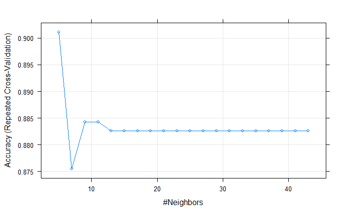

```r
plot(knnFit)
```

# 2 Classification problem using the housing data of sacramento CA

- I am looking at data about sale price for 932 homes in Sacramento CA. I am interested in predicting the price of a house given certain atributes such as the number of beds, the number of baths, squared feet of the property, and type which stand for wether the property is a condo, multi_family or residential. For this I use the median of the variable price as a proxy for the classification.

```r
data("Sacramento")
summary(Sacramento)
```

```
             city          zip           beds           baths            sqft                type         price           latitude       longitude
 SACRAMENTO    :438   z95823 : 61   Min.   :1.000   Min.   :1.000   Min.   : 484   Condo       : 53   Min.   : 30000   Min.   :38.24   Min.   :-121.6
 ELK_GROVE     :114   z95828 : 45   1st Qu.:3.000   1st Qu.:2.000   1st Qu.:1167   Multi_Family: 13   1st Qu.:156000   1st Qu.:38.48   1st Qu.:-121.4
 ROSEVILLE     : 48   z95758 : 44   Median :3.000   Median :2.000   Median :1470   Residential :866   Median :220000   Median :38.62   Median :-121.4
 CITRUS_HEIGHTS: 35   z95835 : 37   Mean   :3.276   Mean   :2.053   Mean   :1680                      Mean   :246662   Mean   :38.59   Mean   :-121.4
 ANTELOPE      : 33   z95838 : 37   3rd Qu.:4.000   3rd Qu.:2.000   3rd Qu.:1954                      3rd Qu.:305000   3rd Qu.:38.69   3rd Qu.:-121.3
 RANCHO_CORDOVA: 28   z95757 : 36   Max.   :8.000   Max.   :5.000   Max.   :4878                      Max.   :884790   Max.   :39.02   Max.   :-120.6
 (Other)       :236   (Other):672
```

```r
median(Sacramento$price)
```

```
[1] 220000
```

```r
pricedum<-ifelse(Sacramento$price > median(Sacramento$price), 1, 0)
Sacramento$pricedum <-pricedum
#Sacramento$pricedum <- factor(Sacramento$pricedum, labels = c("below", "above")) this one creates problem in the caret logistic regression
```

## 2.1 Relevant visual information about the data:

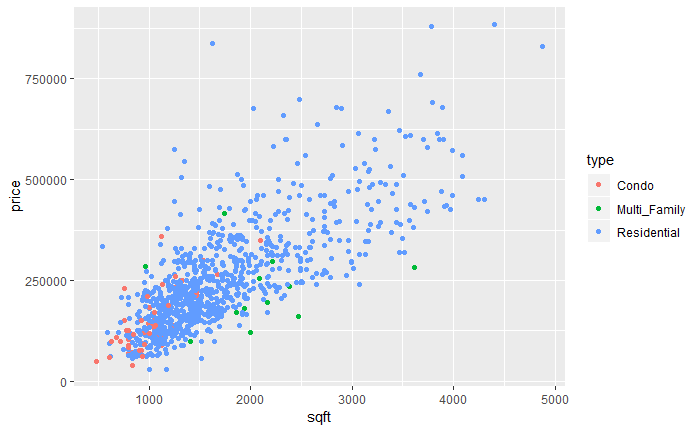

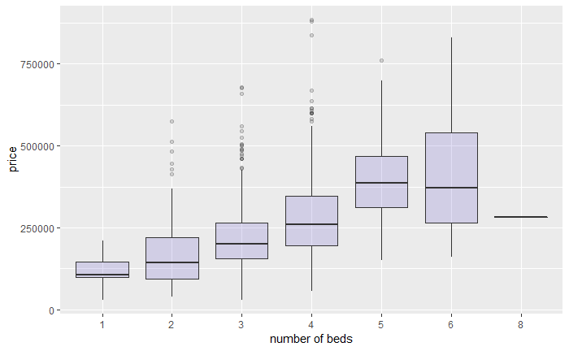

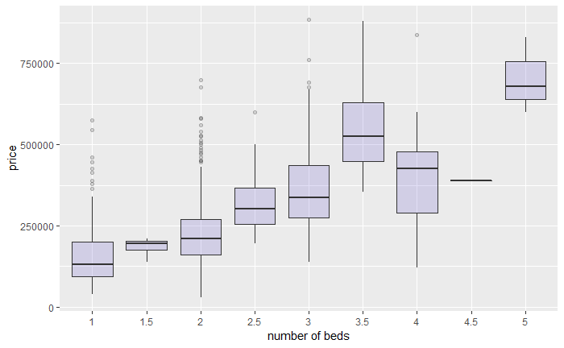

## 2.2 Implementing logistic regression classifier

Implementing the classifier (e.g. logistic regression) using implementations in user-written packages. then I compare the results from the `glm` function in base R to the results from alternative implementations.

```r
require(caTools)
set.seed(123)   #  set seed to ensure you always have same random numbers generated
sample = sample.split(Sacramento,SplitRatio = 0.50) # splits the data in the ratio mentioned in SplitRatio. After splitting marks these rows as logical TRUE and the the remaining are marked as logical FALSE
dtrain =subset(Sacramento,sample ==TRUE) # creates a training dataset named dtrain with rows which are marked as TRUE
dtest=subset(Sacramento, sample==FALSE)
fitControl <- trainControl(## 10-fold CV
  method = "cv",
  number = 10,
  savePredictions = TRUE)
## Logistic regression
lreg2<-train(as.factor(pricedum)~beds+baths+sqft+type,data=dtrain,method="glm",family=binomial(),
             trControl=fitControl)
lreg2
```

```
Generalized Linear Model

466 samples
  4 predictor
  2 classes: '0', '1'

No pre-processing
Resampling: Cross-Validated (10 fold)
Summary of sample sizes: 418, 420, 420, 420, 418, 420, ...
Resampling results:

  Accuracy   Kappa
  0.7876985  0.575408
```

- Kappa, is taking into account the number of positives predicted and positive observed that could of ocurr by random chance.
- The accuracy of .80 implies that the model does a farily good job at predicting the classes.
- The sensitivity of 0.8517 imples that the models does a good job at predicting true positives
- On the other hand, a specificity ratio of 0.7609 implies that there is nearly 76% of true negatives that are correctly predicted as such.

```
Confusion Matrix and Statistics

          Reference
Prediction   0   1
         0 201  55
         1  35 175

               Accuracy : 0.8069
                 95% CI : (0.768, 0.8417)
    No Information Rate : 0.5064
    P-Value [Acc > NIR] : <2e-16

                  Kappa : 0.6132

 Mcnemar's Test P-Value : 0.0452

            Sensitivity : 0.8517
            Specificity : 0.7609
         Pos Pred Value : 0.7852
         Neg Pred Value : 0.8333
             Prevalence : 0.5064
         Detection Rate : 0.4313
   Detection Prevalence : 0.5494
      Balanced Accuracy : 0.8063

       'Positive' Class : 0
```

## 2.3 ROC Curve

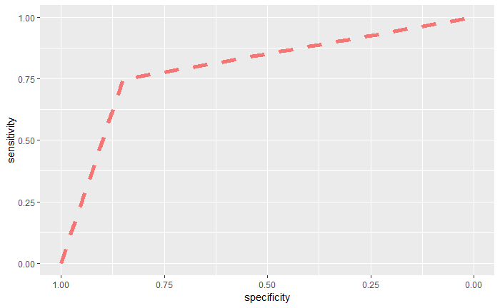

```
Area under the curve: 0.7985
```

5. Assess class imbalance and implement any of the strategies to mitigate it.
- In fact, the random selection of the train sample has produced a well balanced categorical dependent variable. However, if there is the case to manage class imabalance I would use the ROC curve to exploit the far_left point of the curve to find the most efficient probability value in the predictions. Since class imabalance imply a trade off between sensitivity and specificity, I would argue that a change in the probability threshold depends on the class of interest in predicting.

```
        0         1
0.4978541 0.5021459
```

# 3 Naive Bayes classifier

- the basic property of the naive Bayes is the independence assumption between the predictors. The classifier assume that the effect of the value of a predictor on a given class is independent of the values of other predictors. I choose the same parameters as in the logistic regression, the idea is to contrast how both models are doing in terms of predicting the class of interest (pricedum). Interestingly the Bayes classifier underperform by only 4.51 percentage points against the logistic regression.

Naive bayes works extremely well even if the assumption of independence is violated.

```
Naive Bayes Classifier for Discrete Predictors

Call:
naiveBayes.default(x = xTrain, y = as.factor(yTrain), data = xTrain)

A-priori probabilities:
as.factor(yTrain)
        0         1
0.4978541 0.5021459

Conditional probabilities:
                 beds
as.factor(yTrain)     [,1]      [,2]
                0 2.948276 0.7248804
                1 3.602564 0.8235755

                 baths
as.factor(yTrain)     [,1]      [,2]
                0 1.732759 0.5093542
                1 2.350427 0.7154486

                 sqft
as.factor(yTrain)     [,1]     [,2]
                0 1248.987 315.1032
                1 2085.192 745.1431

                 type
as.factor(yTrain)      Condo Multi_Family Residential
                0 0.08620690   0.01724138  0.89655172
                1 0.01709402   0.01282051  0.97008547

Confusion Matrix and Statistics

          Reference
Prediction   0   1
         0 202  81
         1  30 153

               Accuracy : 0.7618
                 95% CI : (0.7205, 0.7998)
    No Information Rate : 0.5021
    P-Value [Acc > NIR] : < 2.2e-16

                  Kappa : 0.524

 Mcnemar's Test P-Value : 2.077e-06

            Sensitivity : 0.8707
            Specificity : 0.6538
         Pos Pred Value : 0.7138
         Neg Pred Value : 0.8361
             Prevalence : 0.4979
         Detection Rate : 0.4335
   Detection Prevalence : 0.6073
      Balanced Accuracy : 0.7623

       'Positive' Class : 0
```